# `Thera Bank Personal Loan Campaign`

## `Domain:`

The dataset contains data on 5000 customers. The data include customer demographic information (age, income, etc.), the customer's relationship with the bank (mortgage, securities account, etc.), and the customer response to the last personal loan campaign (Personal Loan). Among these 5000 customers, only 480 (= 9.6%) accepted the personal loan that was offered to them in the earlier campaign.

## `Context:`

This case is about a bank (Thera Bank) whose management wants to explore ways of converting its liability customers to personal loan customers (while retaining them as depositors). A campaign that the bank ran last year for liability customers showed a healthy conversion rate of over 9% success. This has encouraged the retail marketing department to devise campaigns with better target marketing to increase the success ratio with a minimal budget.

## `Objective:`

The classification goal is to predict the likelihood of a liability customer buying personal loans.

## `Attributes Information:`

- ID: Customer ID
- Age: Customer's age in completed years
- Experience: # years of professional experience
- Income: Annual income of the customer
- ZIP Code: Home Address ZIP code.
- Family: Family size of the customer
- CCAvg: Avg. spending on credit cards per month
- Education: Education Level. 1: Undergrad; 2: Graduate; 3: Advanced/Professional
- Mortgage: Value of house mortgage if any.
- Personal Loan: Did this customer accept the personal loan offered in the last campaign?
- Securities Account: Does the customer have a securities account with the bank?
- CD Account: Does the customer have a certificate of deposit (CD) account with the bank?
- Online: Does the customer use internet banking facilities?
- Credit card: Does the customer use a credit card issued by the bank?

### Import Libraries, Load Dataset, Basic Dataset Checks

```python
# limit warning messages
import warnings
warnings.filterwarnings('ignore')

# import numpy & pandas
import numpy as np
import pandas as pd

# import plot libraries & enable plots in Jupyter notebook
import matplotlib.pyplot as plt
%matplotlib inline
import seaborn as sns

# import training sets & logistic regression features from sklearn
from sklearn.model_selection import train_test_split
from sklearn.linear_model import LogisticRegression
from sklearn.metrics import confusion_matrix, recall_score, precision_score, f1_score, roc_curve, roc_auc_score,accuracy_score

# import advanced metrics from yellowbrick & statsmodels
from yellowbrick.classifier import ClassificationReport, ROCAUC
```

```python
# import dataset from csv file and visualize by printing first 5 rows
df = pd.read_csv('Bank_Personal_Loan_Modelling.csv')
df.head()
```

|  | ID | Age | Experience | Income | ZIP Code | Family | CCAvg | Education | Mortgage | Personal Loan | Securities Account | CD Account | Online | CreditCard |
| --- | --- | --- | --- | --- | --- | --- | --- | --- | --- | --- | --- | --- | --- | --- |
| 0 | 1 | 25 | 1 | 49 | 91107 | 4 | 1.6 | 1 | 0 | 0 | 1 | 0 | 0 | 0 |
| 1 | 2 | 45 | 19 | 34 | 90089 | 3 | 1.5 | 1 | 0 | 0 | 1 | 0 | 0 | 0 |
| 2 | 3 | 39 | 15 | 11 | 94720 | 1 | 1.0 | 1 | 0 | 0 | 0 | 0 | 0 | 0 |
| 3 | 4 | 35 | 9 | 100 | 94112 | 1 | 2.7 | 2 | 0 | 0 | 0 | 0 | 0 | 0 |
| 4 | 5 | 35 | 8 | 45 | 91330 | 4 | 1.0 | 2 | 0 | 0 | 0 | 0 | 0 | 1 |

```python
# check datatypes
df.info()
```

```
<class 'pandas.core.frame.DataFrame'>
RangeIndex: 5000 entries, 0 to 4999
Data columns (total 14 columns):
 #   Column              Non-Null Count  Dtype
---  ------              --------------  -----
 0   ID                  5000 non-null   int64
 1   Age                 5000 non-null   int64
 2   Experience          5000 non-null   int64
 3   Income              5000 non-null   int64
 4   ZIP Code            5000 non-null   int64
 5   Family              5000 non-null   int64
 6   CCAvg               5000 non-null   float64
 7   Education           5000 non-null   int64
 8   Mortgage            5000 non-null   int64
 9   Personal Loan       5000 non-null   int64
 10  Securities Account  5000 non-null   int64
 11  CD Account          5000 non-null   int64
 12  Online              5000 non-null   int64
 13  CreditCard          5000 non-null   int64
dtypes: float64(1), int64(13)
memory usage: 547.0 KB
```

```python
# statistical summary
df.describe().transpose()
```

|  | count | mean | std | min | 25% | 50% | 75% | max |
| --- | --- | --- | --- | --- | --- | --- | --- | --- |
| ID | 5000.0 | 2500.500000 | 1443.520003 | 1.0 | 1250.75 | 2500.5 | 3750.25 | 5000.0 |
| Age | 5000.0 | 45.338400 | 11.463166 | 23.0 | 35.00 | 45.0 | 55.00 | 67.0 |
| Experience | 5000.0 | 20.104600 | 11.467954 | -3.0 | 10.00 | 20.0 | 30.00 | 43.0 |
| Income | 5000.0 | 73.774200 | 46.033729 | 8.0 | 39.00 | 64.0 | 98.00 | 224.0 |
| ZIP Code | 5000.0 | 93152.503000 | 2121.852197 | 9307.0 | 91911.00 | 93437.0 | 94608.00 | 96651.0 |
| Family | 5000.0 | 2.396400 | 1.147663 | 1.0 | 1.00 | 2.0 | 3.00 | 4.0 |
| CCAvg | 5000.0 | 1.937938 | 1.747659 | 0.0 | 0.70 | 1.5 | 2.50 | 10.0 |
| Education | 5000.0 | 1.881000 | 0.839869 | 1.0 | 1.00 | 2.0 | 3.00 | 3.0 |
| Mortgage | 5000.0 | 56.498800 | 101.713802 | 0.0 | 0.00 | 0.0 | 101.00 | 635.0 |
| Personal Loan | 5000.0 | 0.096000 | 0.294621 | 0.0 | 0.00 | 0.0 | 0.00 | 1.0 |
| Securities Account | 5000.0 | 0.104400 | 0.305809 | 0.0 | 0.00 | 0.0 | 0.00 | 1.0 |
| CD Account | 5000.0 | 0.060400 | 0.238250 | 0.0 | 0.00 | 0.0 | 0.00 | 1.0 |
| Online | 5000.0 | 0.596800 | 0.490589 | 0.0 | 0.00 | 1.0 | 1.00 | 1.0 |
| CreditCard | 5000.0 | 0.294000 | 0.455637 | 0.0 | 0.00 | 0.0 | 1.00 | 1.0 |

```python
# shape
df.shape
```

```
(5000, 14)
```

```python
# null values
df.isnull().sum()
```

```
ID                    0
Age                   0
Experience            0
Income                0
ZIP Code              0
Family                0
CCAvg                 0
Education             0
Mortgage              0
Personal Loan         0
Securities Account    0
CD Account            0
Online                0
CreditCard            0
dtype: int64
```

### EDA

```python
# number of unique values in each column
df.nunique()
```

```
ID                    5000
Age                     45
Experience              47
Income                 162
ZIP Code               467
Family                   4
CCAvg                  108
Education                3
Mortgage               347
Personal Loan            2
Securities Account       2
CD Account               2
Online                   2
CreditCard               2
dtype: int64
```

```python
# determine number of people with zero mortgage
df['Mortgage'].value_counts(normalize=False).iloc[lambda x: x.index == 0]

# Answer: 3462
```

```
0    3462
Name: Mortgage, dtype: int64
```

```python
# determine number of people with zero credit card spending per month
df['CCAvg'].value_counts(normalize=False).iloc[lambda x: x.index == 0]

# Answer: 106
```

```
0.0    106
Name: CCAvg, dtype: int64
```

```python
# value counts of all categorical data
print(df["Family"].value_counts(normalize=False))
print()
print(df["Education"].value_counts(normalize=False))
print()
print(df["Personal Loan"].value_counts(normalize=False))
print()
print(df["Securities Account"].value_counts(normalize=False))
print()
print(df["CD Account"].value_counts(normalize=False))
print()
print(df["Online"].value_counts(normalize=False))
print()
print(df["CreditCard"].value_counts(normalize=False))
```

```
1    1472
2    1296
4    1222
3    1010
Name: Family, dtype: int64

1    2096
3    1501
2    1403
Name: Education, dtype: int64

0    4520
1     480
Name: Personal Loan, dtype: int64

0    4478
1     522
Name: Securities Account, dtype: int64

0    4698
1     302
Name: CD Account, dtype: int64

1    2984
0    2016
Name: Online, dtype: int64

0    3530
1    1470
Name: CreditCard, dtype: int64
```

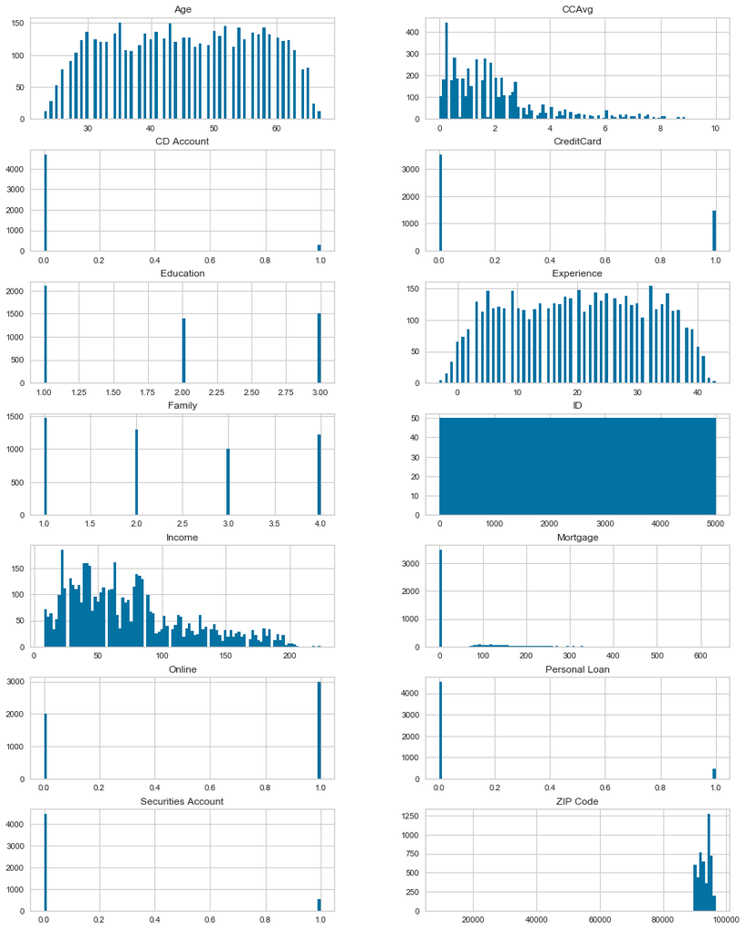

```python
# plot histograms (including categorical)
columns = list(df)[0:]
df[columns].hist(stacked=False, bins=100, figsize=(15,40), layout=(14,2));
```

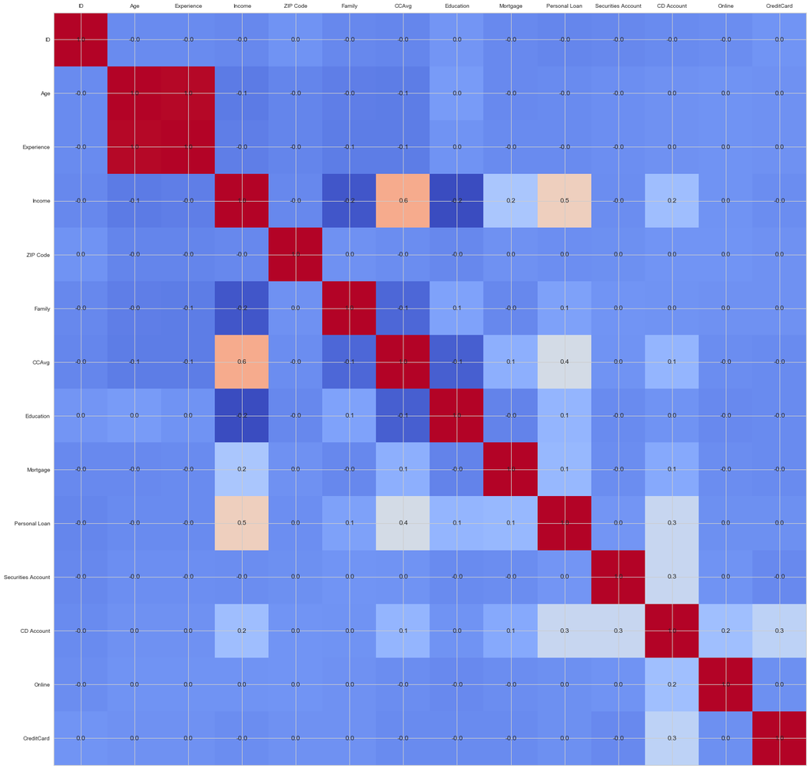

```python
# correlation in data in graphical representation
def plot_corr(cdata, size=25):
    corr = cdata.corr()
    fig, ax = plt.subplots(figsize=(size, size))
    ax.matshow(corr,cmap='coolwarm')
    plt.xticks(range(len(corr.columns)), corr.columns)
    plt.yticks(range(len(corr.columns)), corr.columns)
    for (i, j), z in np.ndenumerate(corr):
        ax.text(j, i, '{:0.1f}'.format(z), ha='center', va='center')
plot_corr(df)
```

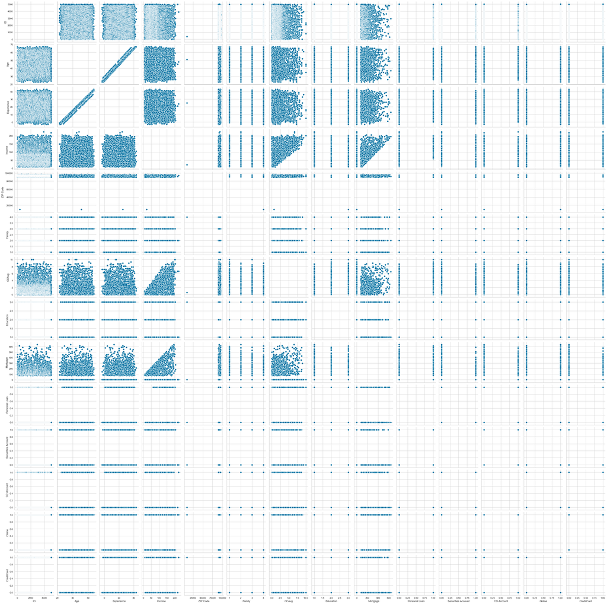

```python
# pairplot
sns.pairplot(df,diag_kind='scatter')
```

```python
# Get data model ready
```

```python
# create dataset to modify for data model from the original dataset
plc_df = df.copy()
plc_df.head()
```

|  | ID | Age | Experience | Income | ZIP Code | Family | CCAvg | Education | Mortgage | Personal Loan | Securities Account | CD Account | Online | CreditCard |
| --- | --- | --- | --- | --- | --- | --- | --- | --- | --- | --- | --- | --- | --- | --- |
| 0 | 1 | 25 | 1 | 49 | 91107 | 4 | 1.6 | 1 | 0 | 0 | 1 | 0 | 0 | 0 |
| 1 | 2 | 45 | 19 | 34 | 90089 | 3 | 1.5 | 1 | 0 | 0 | 1 | 0 | 0 | 0 |
| 2 | 3 | 39 | 15 | 11 | 94720 | 1 | 1.0 | 1 | 0 | 0 | 0 | 0 | 0 | 0 |
| 3 | 4 | 35 | 9 | 100 | 94112 | 1 | 2.7 | 2 | 0 | 0 | 0 | 0 | 0 | 0 |
| 4 | 5 | 35 | 8 | 45 | 91330 | 4 | 1.0 | 2 | 0 | 0 | 0 | 0 | 0 | 1 |

```python
# convert applicable columns from numerical to category columns
plc_df['Family'] = plc_df['Family'].astype('category')
plc_df['Education'] = plc_df['Education'].astype('category')
plc_df['Personal Loan'] = plc_df['Personal Loan'].astype('category')
plc_df['Securities Account'] = plc_df['Securities Account'].astype('category')
plc_df['CD Account'] = plc_df['CD Account'].astype('category')
plc_df['Online'] = plc_df['Online'].astype('category')
plc_df['CreditCard'] = plc_df['CreditCard'].astype('category')

plc_df.info()
```

```
<class 'pandas.core.frame.DataFrame'>
RangeIndex: 5000 entries, 0 to 4999
Data columns (total 14 columns):
 #   Column              Non-Null Count  Dtype
---  ------              --------------  -----
 0   ID                  5000 non-null   int64
 1   Age                 5000 non-null   int64
 2   Experience          5000 non-null   int64
 3   Income              5000 non-null   int64
 4   ZIP Code            5000 non-null   int64
 5   Family              5000 non-null   category
 6   CCAvg               5000 non-null   float64
 7   Education           5000 non-null   category
 8   Mortgage            5000 non-null   int64
 9   Personal Loan       5000 non-null   category
 10  Securities Account  5000 non-null   category
 11  CD Account          5000 non-null   category
 12  Online              5000 non-null   category
 13  CreditCard          5000 non-null   category
dtypes: category(7), float64(1), int64(6)
memory usage: 308.5 KB
```

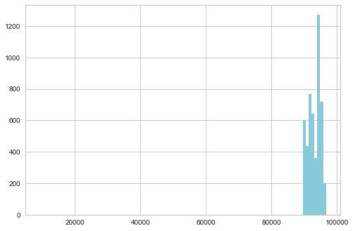

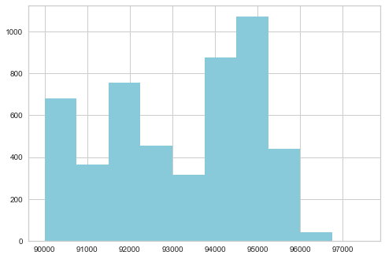

```python
# Try to make ZIP code more usuable; visualize distribution
plt.hist(plc_df['ZIP Code'], bins=100, color='C')
plt.show()
plt.hist(plc_df['ZIP Code'], bins=10, color='C', range=(90000,97500))
plt.show()
```

```python
# determine ZIP Code outliers (range 90000-97500)
plc_df.loc[(plc_df['ZIP Code'] < 90000) | (plc_df['ZIP Code'] > 97500)]
```

|  | ID | Age | Experience | Income | ZIP Code | Family | CCAvg | Education | Mortgage | Personal Loan | Securities Account | CD Account | Online | CreditCard |
| --- | --- | --- | --- | --- | --- | --- | --- | --- | --- | --- | --- | --- | --- | --- |
| 384 | 385 | 51 | 25 | 21 | 9307 | 4 | 0.6 | 3 | 0 | 0 | 0 | 0 | 1 | 1 |

```python
# impute ZIP code outlier value by setting its value  to most common ZIP code
print(plc_df.loc[384,'ZIP Code'])
plc_df.at[384,'ZIP Code'] = plc_df['ZIP Code'].mode()
print(plc_df.loc[384,'ZIP Code'])
```

```
9307
94720
```

```python
# Group ZIP Code into 10 bins
bin_edges = [90000, 90750, 91500, 92250, 93000, 93750, 94500, 95250, 96000, 96750, 97500] # edges to define intervals
bin_labels = ['90000-90750', '90750-91500', '91500-92250', '92250-93000','93000-93750', '93750-94500', '94500-95250',
              '95250-96000','96000-96750', '96750-97500']               # labels to denote each interval
plc_df['ZIP Code'] = pd.cut(plc_df['ZIP Code'], bins=bin_edges , labels=bin_labels)

# Convert ZIP Code to categorical data
plc_df['ZIP Code'] = plc_df['ZIP Code'].astype('category')

# Check value counts to verify data split into 10 bins
plc_df['ZIP Code'].value_counts(normalize=False)
```

```
94500-95250    1073
93750-94500     878
91500-92250     757
90000-90750     681
92250-93000     454
95250-96000     439
90750-91500     364
93000-93750     314
96000-96750      40
96750-97500       0
Name: ZIP Code, dtype: int64
```

```python
# re-check datatypes
plc_df.info()
```

```
<class 'pandas.core.frame.DataFrame'>
RangeIndex: 5000 entries, 0 to 4999
Data columns (total 14 columns):
 #   Column              Non-Null Count  Dtype
---  ------              --------------  -----
 0   ID                  5000 non-null   int64
 1   Age                 5000 non-null   int64
 2   Experience          5000 non-null   int64
 3   Income              5000 non-null   int64
 4   ZIP Code            5000 non-null   category
 5   Family              5000 non-null   category
 6   CCAvg               5000 non-null   float64
 7   Education           5000 non-null   category
 8   Mortgage            5000 non-null   int64
 9   Personal Loan       5000 non-null   category
 10  Securities Account  5000 non-null   category
 11  CD Account          5000 non-null   category
 12  Online              5000 non-null   category
 13  CreditCard          5000 non-null   category
dtypes: category(8), float64(1), int64(5)
memory usage: 274.7 KB
```

### Split Data Into Training and Test Sets

```python
# Define X and Y variables
X = plc_df.drop(columns=['ID', 'Personal Loan'], axis=1)   # Define X without 'ID' and 'Personal Loan' columns
y = plc_df['Personal Loan']
```

```python
# Create binary fields from categorical fields
X = pd.get_dummies(X, drop_first=True)
X.head()
```

|  | Age | Experience | Income | CCAvg | Mortgage | ZIP Code_90750-91500 | ZIP Code_91500-92250 | ZIP Code_92250-93000 | ZIP Code_93000-93750 | ZIP Code_93750-94500 | ... | ZIP Code_96750-97500 | Family_2 | Family_3 | Family_4 | Education_2 | Education_3 | Securities Account_1 | CD Account_1 | Online_1 | CreditCard_1 |
| --- | --- | --- | --- | --- | --- | --- | --- | --- | --- | --- | --- | --- | --- | --- | --- | --- | --- | --- | --- | --- | --- |
| 0 | 25 | 1 | 49 | 1.6 | 0 | 1 | 0 | 0 | 0 | 0 | ... | 0 | 0 | 0 | 1 | 0 | 0 | 1 | 0 | 0 | 0 |
| 1 | 45 | 19 | 34 | 1.5 | 0 | 0 | 0 | 0 | 0 | 0 | ... | 0 | 0 | 1 | 0 | 0 | 0 | 1 | 0 | 0 | 0 |
| 2 | 39 | 15 | 11 | 1.0 | 0 | 0 | 0 | 0 | 0 | 0 | ... | 0 | 0 | 0 | 0 | 0 | 0 | 0 | 0 | 0 | 0 |
| 3 | 35 | 9 | 100 | 2.7 | 0 | 0 | 0 | 0 | 0 | 1 | ... | 0 | 0 | 0 | 0 | 1 | 0 | 0 | 0 | 0 | 0 |
| 4 | 35 | 8 | 45 | 1.0 | 0 | 1 | 0 | 0 | 0 | 0 | ... | 0 | 0 | 0 | 1 | 1 | 0 | 0 | 0 | 0 | 1 |

5 rows × 23 columns

```python
# Split into training and test set (~70% Training / ~30% Test )
X_train, X_test, y_train, y_test = train_test_split(X, y, test_size=0.3, random_state = 1)
```

```python
# Print # of records to verify split
print(X_train.shape)
print(X_test.shape)
print(y_train.shape)
print(y_test.shape)
```

```
(3500, 23)
(1500, 23)
(3500,)
(1500,)
```

### Build Baseline Logistic Regression Model

```python
# Define the model
logreg = LogisticRegression(random_state=1)
logreg.fit(X_train, y_train)
```

```
LogisticRegression(C=1.0, class_weight=None, dual=False, fit_intercept=True,
                   intercept_scaling=1, l1_ratio=None, max_iter=100,
                   multi_class='auto', n_jobs=None, penalty='l2',
                   random_state=1, solver='lbfgs', tol=0.0001, verbose=0,
                   warm_start=False)
```

```python
# Create prediction model
y_predict = logreg.predict(X_test)
```

```python
# Create function to format confusion matrix
def draw_cm( actual, predicted ):
    cm = confusion_matrix( actual, predicted)
    sns.heatmap(cm, annot=True,  fmt='.2f', xticklabels = [0,1] , yticklabels = [0,1] )
    plt.ylabel('Observed')
    plt.xlabel('Predicted')
    plt.show()
```

```
Training accuracy:  0.9614285714285714
 Testing accuracy:  0.9506666666666667

Confusion Matrix:
```

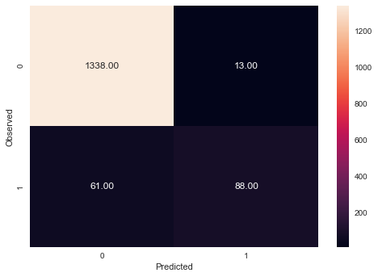

```
None

       Recall:  0.5906040268456376
    Precision:  0.8712871287128713
     F1 Score:  0.7040000000000001
Roc Auc Score:  0.7904907624975783
```

```python
print("Training accuracy: ",logreg.score(X_train,y_train))
print(" Testing accuracy: ",logreg.score(X_test, y_test))
print()
print('Confusion Matrix:')
print(draw_cm(y_test,y_predict))
print()
print("       Recall: ",recall_score(y_test,y_predict))
print("    Precision: ",precision_score(y_test,y_predict))
print("     F1 Score: ",f1_score(y_test,y_predict))
print("Roc Auc Score: ",roc_auc_score(y_test,y_predict))
```

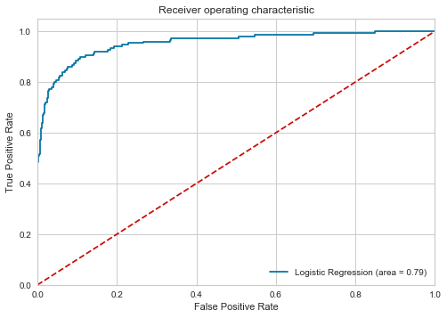

```python
# Create AUC ROC Curve from Yellowbrick library

logit_roc_auc = roc_auc_score(y_test, logreg.predict(X_test))
fpr, tpr, thresholds = roc_curve(y_test, logreg.predict_proba(X_test)[:,1])
plt.figure()
plt.plot(fpr, tpr, label='Logistic Regression (area = %0.2f)' % logit_roc_auc)
plt.plot([0, 1], [0, 1],'r--')
plt.xlim([0.0, 1.0])
plt.ylim([0.0, 1.05])
plt.xlabel('False Positive Rate')
plt.ylabel('True Positive Rate')
plt.title('Receiver operating characteristic')
plt.legend(loc="lower right")
plt.savefig('Log_ROC')
plt.show()
```

### Improving Model Performance

```python
# Checking Parameters of logistic regression
logreg.get_params()
```

```
{'C': 1.0,
 'class_weight': None,
 'dual': False,
 'fit_intercept': True,
 'intercept_scaling': 1,
 'l1_ratio': None,
 'max_iter': 100,
 'multi_class': 'auto',
 'n_jobs': None,
 'penalty': 'l2',
 'random_state': 1,
 'solver': 'lbfgs',
 'tol': 0.0001,
 'verbose': 0,
 'warm_start': False}
```

```python
# Loop through all solvers for l2 (i.e. all solvers)
train_score=[]
test_score=[]
solver = ['newton-cg','lbfgs','liblinear','sag','saga']
for i in solver:
    model = LogisticRegression(random_state=1,penalty='l2', C = 0.75,solver=i)  # changing values of solver
    model.fit(X_train, y_train)
    y_predict = model.predict(X_test)
    train_score.append(round(model.score(X_train, y_train),3))
    test_score.append(round(model.score(X_test, y_test),3))

print("     Solver:", solver)
print("Train Score:", train_score)
print(" Test Score:", test_score)
```

```
     Solver: ['newton-cg', 'lbfgs', 'liblinear', 'sag', 'saga']
Train Score: [0.962, 0.961, 0.96, 0.908, 0.907]
 Test Score: [0.954, 0.951, 0.951, 0.901, 0.905]
```

```python
# Loop through all solvers for l1 (i.e. only 'liblinear' and 'saga')
train_score=[]
test_score=[]
solver = ['liblinear','saga']
for i in solver:
    model = LogisticRegression(random_state=1,penalty='l1', C = 0.75,solver=i)  #changed penalty to 'l1'
    model.fit(X_train, y_train)
    y_predict = model.predict(X_test)
    train_score.append(round(model.score(X_train, y_train),3))
    test_score.append(round(model.score(X_test, y_test),3))

print("     Solver:", solver)
print("Train Score:", train_score)
print(" Test Score:", test_score)
```

```
     Solver: ['liblinear', 'saga']
Train Score: [0.963, 0.907]
 Test Score: [0.954, 0.905]
```

```python
## We note that highest accuracy is the same with 'L1 liblinear' as 'L2 newton-cg'
# We can choose either one
```

```python
# We choose 'L1 liblinear' and change class_weight to 'balanced'
model = LogisticRegression(random_state=1,penalty='l1',solver='liblinear',class_weight='balanced')
model.fit(X_train, y_train)
y_predict = model.predict(X_test)

print("Training accuracy: ",model.score(X_train,y_train))
print(" Testing accuracy: ",model.score(X_test, y_test))
```

```
Training accuracy:  0.9162857142857143
 Testing accuracy:  0.9113333333333333
```

```python
## Testing accuracy decreased so we try with class_weight to 'none'
```

```python
# We choose 'L1 liblinear' and change class_weight to 'none'
model = LogisticRegression(random_state=1,penalty='l1',solver='liblinear',class_weight=None)
model.fit(X_train, y_train)
y_predict = model.predict(X_test)

print("Training accuracy: ",model.score(X_train,y_train))
print(" Testing accuracy: ",model.score(X_test, y_test))
```

```
Training accuracy:  0.9622857142857143
 Testing accuracy:  0.956
```

```python
## Accuracy is better with class_weight=None so we will use that
```

```python
# Loop through values of 'C' and check for improvements
train_score=[]
test_score=[]
C = [0.01,0.1,0.25,0.5,0.75, 1]
for i in C:
    model = LogisticRegression(random_state=1,penalty='l1', solver='liblinear',class_weight=None, C=i)  # changing values of C
    model.fit(X_train, y_train)
    y_predict = model.predict(X_test)
    train_score.append(round(model.score(X_train,y_train),3)) # appending training accuracy in a blank list for every run of the loop
    test_score.append(round(model.score(X_test, y_test),3))   # appending testing accuracy in a blank list for every run of the loop

print("    C-Value:", C)
print("Train Score:", train_score)
print(" Test Score:", test_score)
```

```
    C-Value: [0.01, 0.1, 0.25, 0.5, 0.75, 1]
Train Score: [0.906, 0.956, 0.959, 0.963, 0.963, 0.962]
 Test Score: [0.905, 0.949, 0.951, 0.953, 0.954, 0.956]
```

```python
## Accuracy is best for C=1
```

```
Training accuracy:  0.9622857142857143
 Testing accuracy:  0.956

Confusion Matrix
```

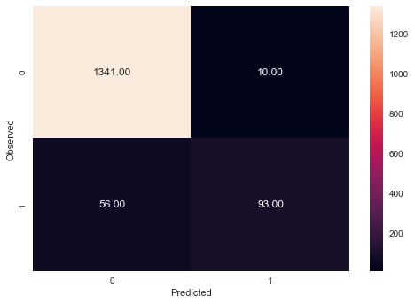

```
None

       Recall:  0.6241610738255033
    Precision:  0.9029126213592233
     F1 Score:  0.738095238095238
Roc Auc Score:  0.8083795746625666
```

```python
# Final Model is
model = LogisticRegression(random_state=42,penalty='l1', solver='liblinear', class_weight=None,C=1.0)
model.fit(X_train, y_train)
y_predict = model.predict(X_test)

print("Training accuracy: ",model.score(X_train,y_train))
print(" Testing accuracy: ",model.score(X_test, y_test))
print()
print('Confusion Matrix')
print(draw_cm(y_test,y_predict))
print()
print("       Recall: ",recall_score(y_test,y_predict))
print("    Precision: ",precision_score(y_test,y_predict))
print("     F1 Score: ",f1_score(y_test,y_predict))
print("Roc Auc Score: ",roc_auc_score(y_test,y_predict))
```

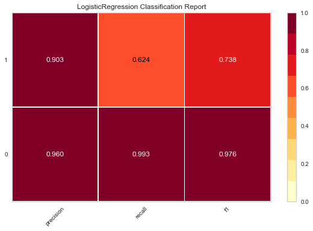

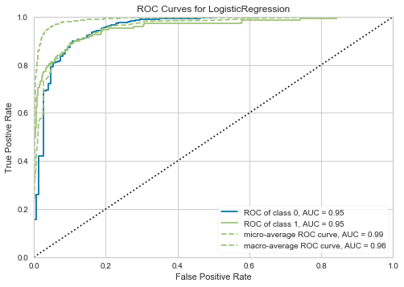

```python
# Visualize model performance with yellowbrick library
viz = ClassificationReport(model)
viz.fit(X_train, y_train)
viz.score(X_test, y_test)
viz.show()

roc = ROCAUC(model)
roc.fit(X_train, y_train)
roc.score(X_test, y_test)
roc.show()
```

### Business Insights

`Confusion matrix means`

**True Positive (observed=1,predicted=1):** --> Predicted that customer takes loan and the customer takes loan

**False Positive (observed=0,predicted=1):** --> Predicted that customer takes loan but customer does not take loan

**True Negative (observed=0,predicted=0):** --> Predicted that customer does not take and customer does not take loan

**False Negative (observed=1,predicted=0):** --> Predicted that customer does not take loan but customer takes loan

Here the bank wants to better target their marketing towards customers that have the highest likelihood of taking a Personal Loan. **False Negatives is the important metric** because this is missed revenue by customers that would have taken loans. Hence **Recall is the important metric**.

In the case of False Positives, the bank would lose minimal marketing costs.

In the case of False Negatives, the bank would miss revenue from missed loans that customers would have taken.